# adding RVs

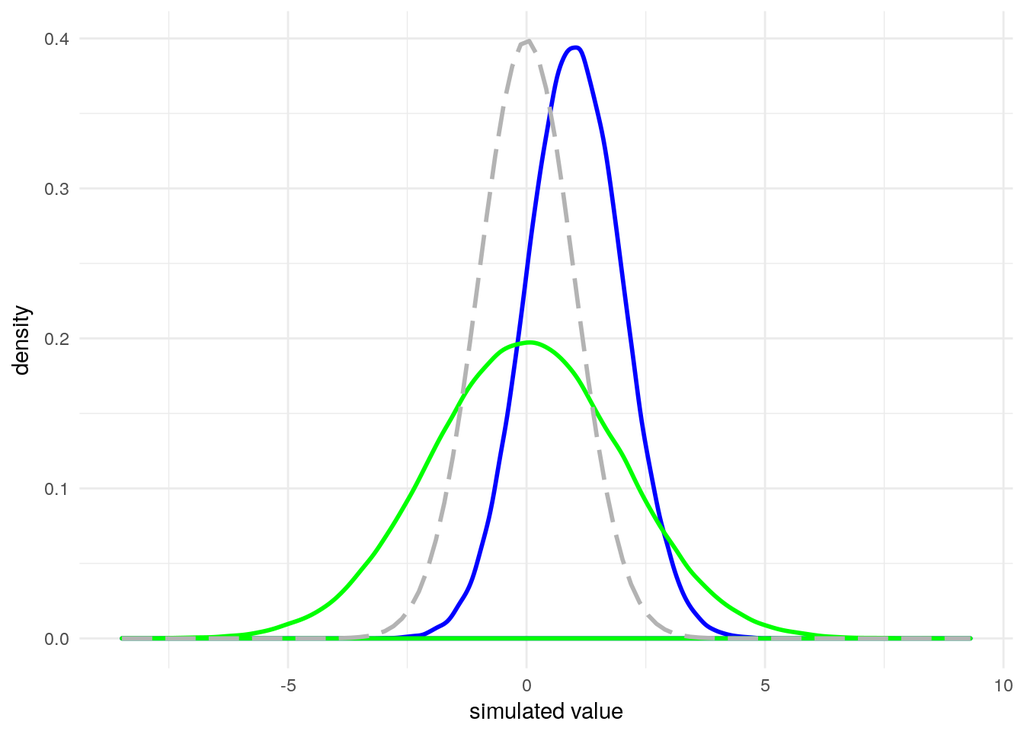

```r
ggplot(norms) + geom_density(aes(A), color="blue", size=1) +
  geom_density(aes(B), color="green", size=1) +
  stat_function(fun=dnorm, args=list(mean=0,
                                     sd=1), color="grey70", size=1, linetype=5) +
  theme_minimal() + xlab("simulated value")
```

Comparing one A (dashed) with 2 As in blue and one B (dashed) with 2 Bs in green B. $N(0,1)$ in dashed grey in each.

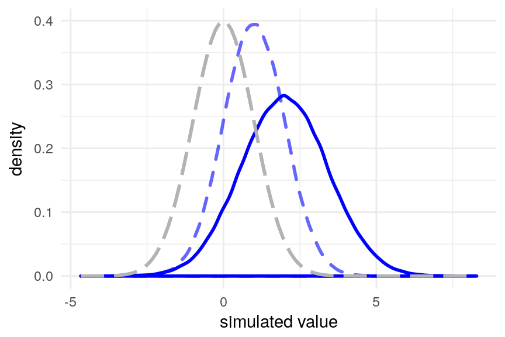

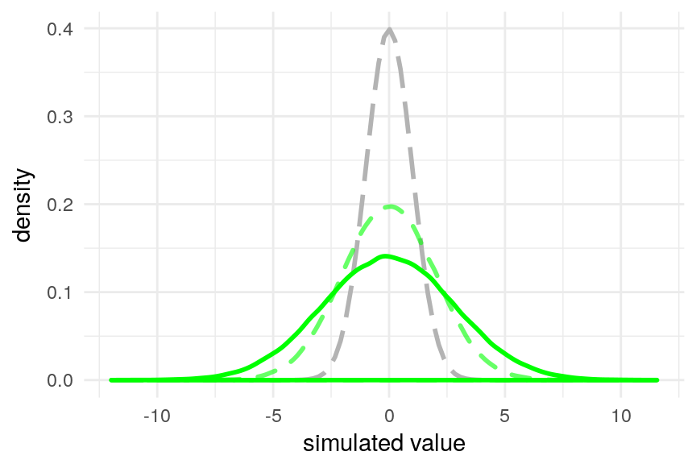

```r
ggplot(norms) + stat_function(fun=dnorm, args=list(mean=0,
                                     sd=1), color="grey70", size=1, linetype=5) +
  geom_density(aes(Atwo), color="blue", size=1) +
  geom_density(aes(A), color=alpha("blue",0.6), size=1, linetype=2) +
  stat_function(fun=dnorm, args=list(mean=0,
                                     sd=1), color="grey70", size=1, linetype=5) +
  theme_minimal() + labs(x="simulated value", y="density")

ggplot(norms) + stat_function(fun=dnorm, args=list(mean=0,
                                     sd=1), color="grey70", size=1, linetype=5) +
  geom_density(aes(Btwo), color="green", size=1) +
  geom_density(aes(B), color=alpha("green",0.6), size=1, linetype=2) +
  theme_minimal() + labs(x="simulated value", y="density")
```

Comparing one A (dashed) with sums of As (2,3,4,5) in blue, $N(0,1)$ in dashed grey.

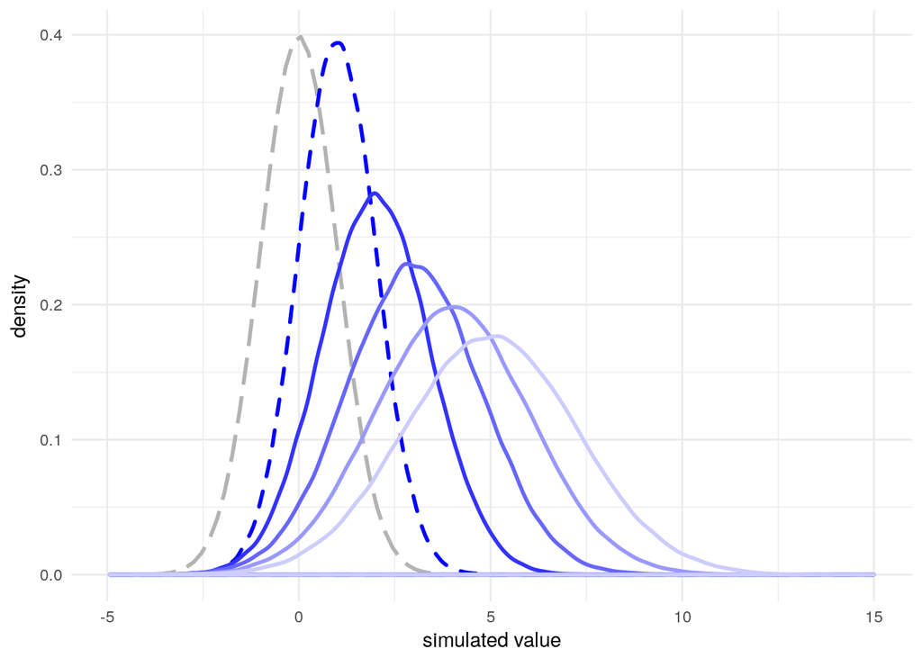

```r
ggplot(norms) + stat_function(fun=dnorm, args=list(mean=0,
                                     sd=1), color="grey70", size=1, linetype=5) +
  geom_density(aes(A), color="#0000ff", size=1, linetype=2) +
  geom_density(aes(Atwo), color="#3333ff", size=1) +
  geom_density(aes(Athree), color="#6666ff", size=1) +
  geom_density(aes(Afour), color="#9999ff", size=1) +
  geom_density(aes(Afive), color="#ccccff", size=1) +
  theme_minimal() + labs(x="simulated value", y="density")
```

Comparing one B (dashed) with sums of Bs (2,3,4,5) in green, $N(0,1)$ in dashed grey.

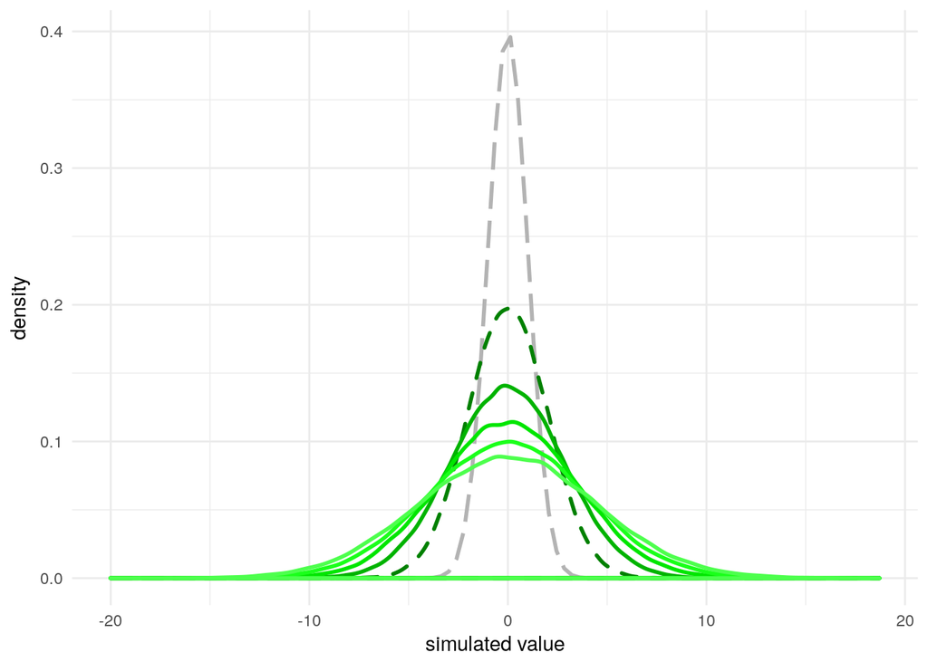

```r
ggplot(norms) + stat_function(fun=dnorm, args=list(mean=0,
                                     sd=1), color="grey70", size=1, linetype=5) +
  geom_density(aes(B), color="#008000", size=1, linetype=2) +
  geom_density(aes(Btwo), color="#00b300", size=1) +
  geom_density(aes(Bthree), color="#00e600", size=1) +
  geom_density(aes(Bfour), color="#1aff1a", size=1) +
  geom_density(aes(Bfive), color="#4dff4d", size=1) +
  theme_minimal()  + labs(x="simulated value", y="density")
```

Now add three different Normals:  
$N(0,1)$ + $N(1,1)$ + $N(0,2)$

```r
norms$ZAB <- norms$Z + norms$A + norms$B
```

plot `Z+A+B` which should be $N(1,\sqrt6)$ since:  
$\mu=0+0+1$ and,  
$sd=\sqrt{1^2+1^2+2^2}=\sqrt6$  
histogram on the left, on the right is the density of ZAB in blue and $N(1,\sqrt6)$ in orange:

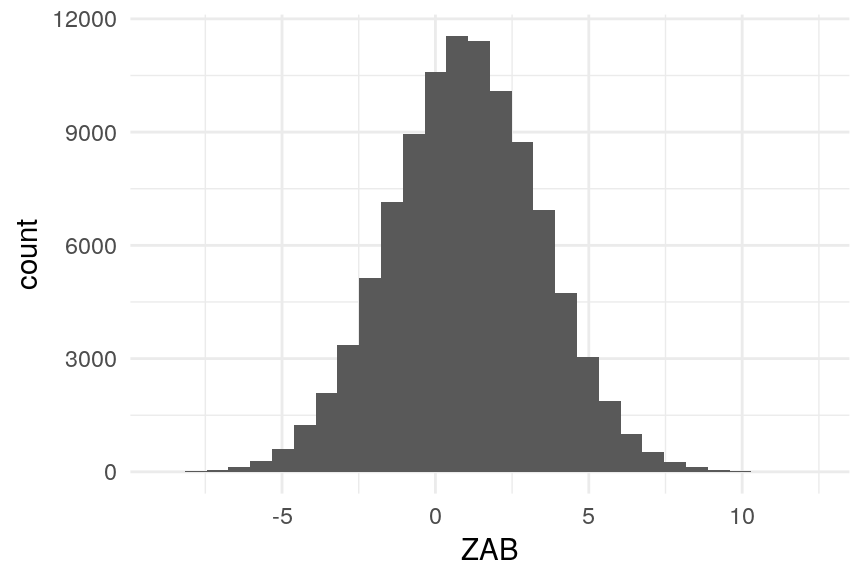

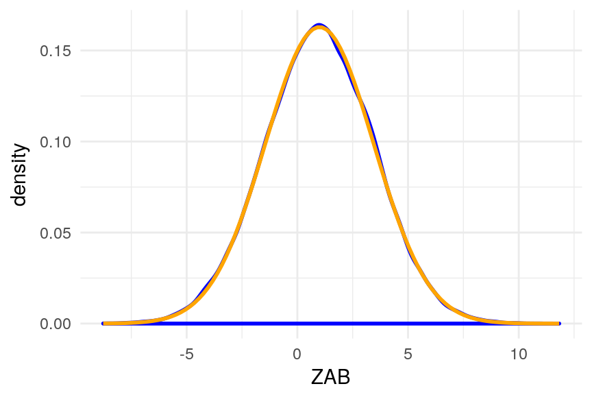

```r
ggplot(norms, aes(ZAB)) + geom_histogram() + theme_minimal()
ggplot(norms, aes(ZAB)) + geom_density(color="blue", size=1) +
  stat_function(fun=dnorm, args=list(mean=1,
                                     sd=sqrt(6)), color="orange", size=1) +
  theme_minimal()
```

Overlay of Z ($N(0,1)$) in orange, A ($N(1,1)$) in green, and B ($N(0,2)$) in red, with the result of Z+A+B ($N(1,\sqrt6)$) in blue and theoretical $N(1,\sqrt6)$ in grey dots.

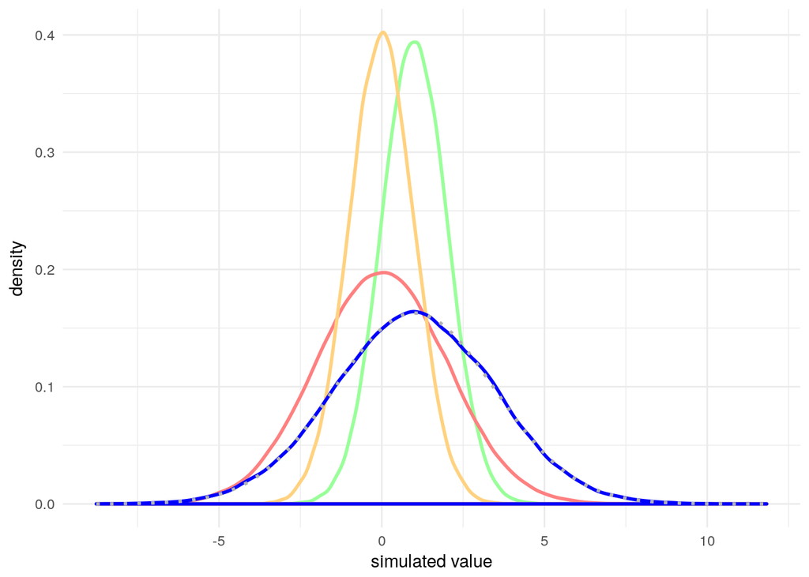

```r
ggplot(norms) + geom_density(aes(A), color="#99ff99", size=1) +
  geom_density(aes(B), color="#ff8080", size=1) +
  geom_density(aes(Z), color="#ffd280", size=1) +
  geom_density(aes(ZAB), color="blue", size=1) +
  stat_function(fun=dnorm, args=list(mean=1,
                                     sd=sqrt(6)), color="grey70", size=1, linetype=3) +
  theme_minimal() + xlab("simulated value")
```